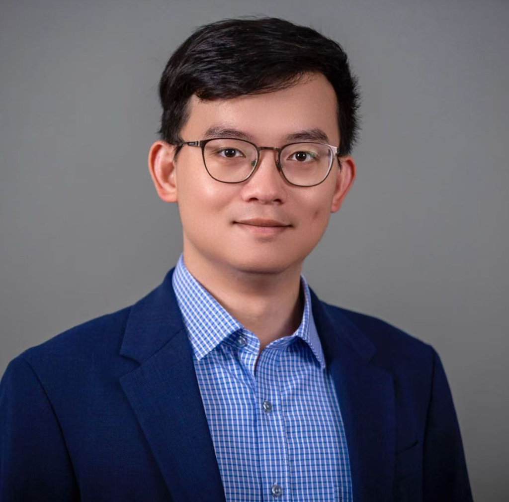

# Jingyuan Qian

## Bio

Welcome! My name is Jingyuan Qian, and I am an Assistant Professor in the [Department of Political Science](https://www.bc.edu/bc-web/schools/morrissey/departments/political-science.html) at [Boston College](https://www.bc.edu/).

My research focuses on statebuilding, political institutions, and political economy in historical and modern non-democratic regimes, with a regional emphasis on China and East Asia. I examine how those regimes design institutions and mechanisms to monitor and control local and subordinate bureaucrats and to ensure their compliance with the leaders’ policy agenda. I also study the short- and long-term effects of political institutions on regime stability, socioeconomic outcomes, and citizens’ political attitudes.

My book manuscript, titled *Statebuilding by Campaign: The Making of Modern Chinese Bureaucracy, 1949-76*, studies the various mechanisms employed by the Chinese regime under Chairman Mao Zedong to motivate and control subordinate bureaucrats during the first three decades of the People’s Republic. Additionally, my works on Chinese and East Asian politics have been published in *[Comparative Politics](https://doi.org/10.5129/001041524X17069685289697)*, *[Studies in Comparative International Development](https://doi.org/10.1007/s12116-026-09501-w)*, *[The China Quarterly](https://doi.org/10.1017/S0305741023000644)*, *[Ethnopolitics](https://doi.org/10.1080/17449057.2021.2001954)*, among others.

As an educator, I teach courses in Chinese and East Asian politics, comparative politics, game theory, and political methodology. My interviews and commentaries have been featured in major media outlets around the world, including [Bloomberg TV](https://www.bloomberg.com/live), *[The Atlantic](https://www.theatlantic.com/)*, *[South China Morning Post](https://www.scmp.com/)*, *[Made in China Journal](https://madeinchinajournal.com/)*, [Initium Media](https://theinitium.com/), and Azerbaijan’s [ARB 24 News Channel](https://www.arb24.arbtv.az/).

## Education

Ph.D. in Political Science, [University of Wisconsin-Madison](https://polisci.wisc.edu/) | 2018 - 23

Master of Public Policy, [Georgetown University](https://mccourt.georgetown.edu/) | 2014 - 16

B.A. in Political Science, [Macalester College](https://www.macalester.edu/) | 2010 - 14

## Employment

Assistant Professor in Political Science, [Boston College](https://www.bc.edu/bc-web/schools/morrissey/departments/political-science.html) | 2025 - Present

Earl Johnson Lecturer in Political Science, [University of Chicago](https://mapss.uchicago.edu/) | 2023 - 25

Associate in Research, [Duke-Margolis Institute](https://healthpolicy.duke.edu/) | 2016 - 18